# Лабораторна робота №2: Кластеризація

Яценко Мар’яна Ярославівна, Варіант 10 (USJudgeRatings)

2026-05-04

## 1. Опис датасету

У цій роботі аналізується набір даних `USJudgeRatings`, який містить оцінки адвокатами різних суддів за 12 критеріями (чесність, старанність, поведінка тощо).

Кількість об’єктів (суддів) дорівнює 43, а кількість ознак — 12. Пропусків у даних не виявлено. Імена суддів були використані як ідентифікатори рядків і не включалися в матрицю ознак.

Таблиця 1. Фрагмент вихідних даних

|  | CONT | INTG | DMNR | DILG | CFMG | DECI |
| --- | --- | --- | --- | --- | --- | --- |
| AARONSON,L.H. | 5.7 | 7.9 | 7.7 | 7.3 | 7.1 | 7.4 |
| ALEXANDER,J.M. | 6.8 | 8.9 | 8.8 | 8.5 | 7.8 | 8.1 |
| ARMENTANO,A.J. | 7.2 | 8.1 | 7.8 | 7.8 | 7.5 | 7.6 |
| BERDON,R.I. | 6.8 | 8.8 | 8.5 | 8.8 | 8.3 | 8.5 |
| BRACKEN,J.J. | 7.3 | 6.4 | 4.3 | 6.5 | 6.0 | 6.2 |

## 2. Підготовка даних

Оскільки ознаки оцінювання можуть мати різну дисперсію, перед кластеризацією було виконано стандартизацію даних за допомогою функції `scale()`. Це дозволило збалансувати вплив усіх змінних на обчислення відстаней.

```r
# Код, що використовувався для масштабування та збереження чистих даних
df_scaled <- as.data.frame(scale(df_raw))
write.csv(df_scaled, file = "../data/clean_USJudgeRatings.csv")
```

## 3. Ієрархічна кластеризація

Було побудовано дендрограми двома методами: **Ward.D2** та **Average**. Розрахунок кофенетичної кореляції показав, що метод Average краще зберігає структуру вихідних відстаней (0.809) порівняно з методом Ward.D2 (0.580).

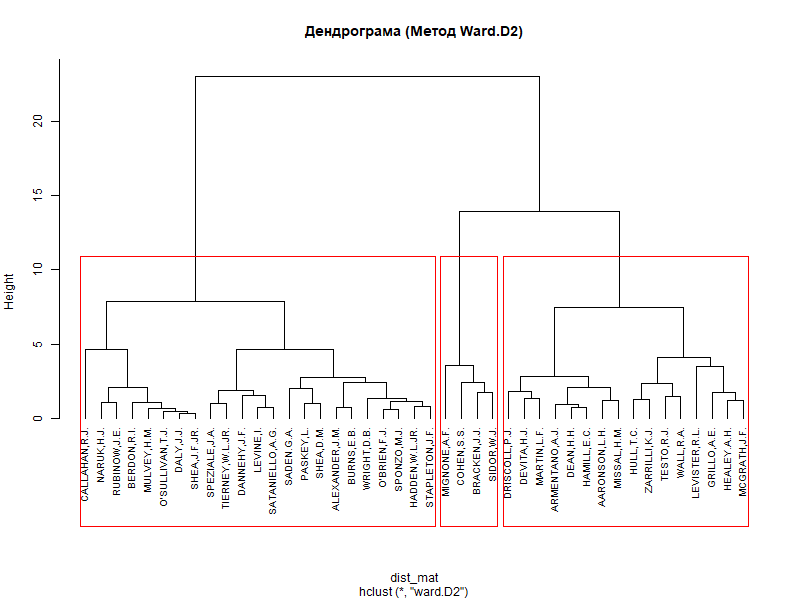

Рис 1. Дендрограма методу Ward.D2

## 4. Вибір кількості кластерів

Для визначення оптимальної кількості кластерів ($k$) було використано метод ліктя та метод середнього силуету.

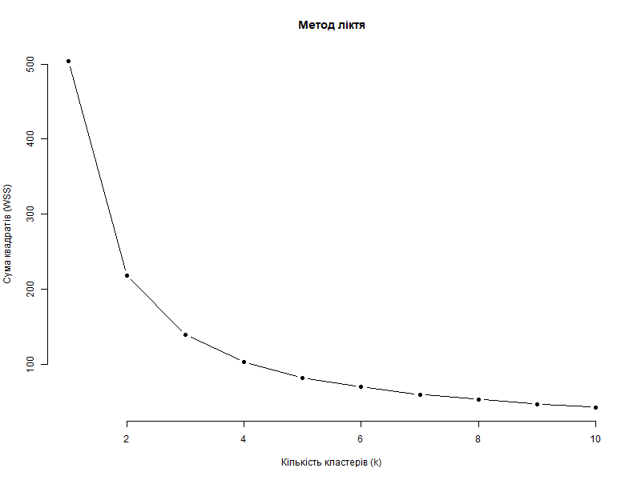

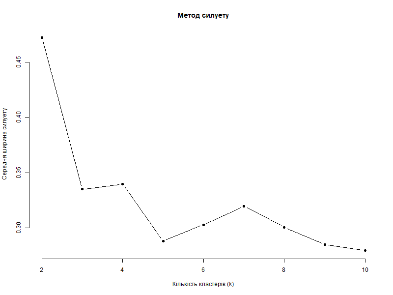

На графіку силуету спостерігається чіткий пік при $k=2$. Метод ліктя також показує злам на цьому значенні. Отже, фінальне число кластерів: **2**.

## 5. Порівняння методів та Профілі кластерів

Було виконано розбиття на 2 кластери методами **k-means** та **PAM**. Значення ARI між k-means та PAM склало **0.904**, що свідчить про майже ідентичне розбиття та високу стабільність результату.

Таблиця 2. Належність суддів до кластерів

[output not shown]

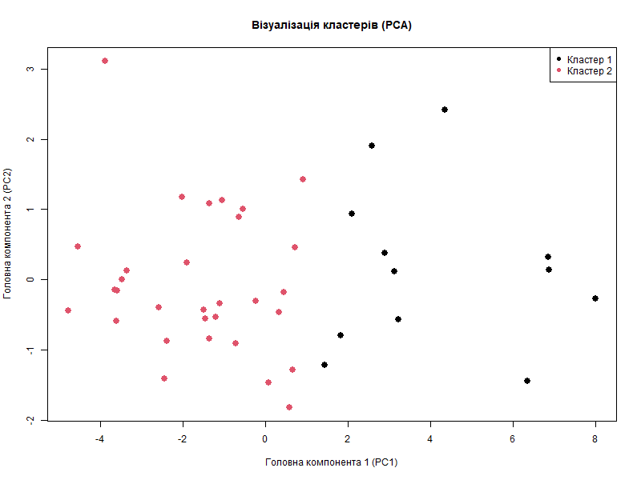

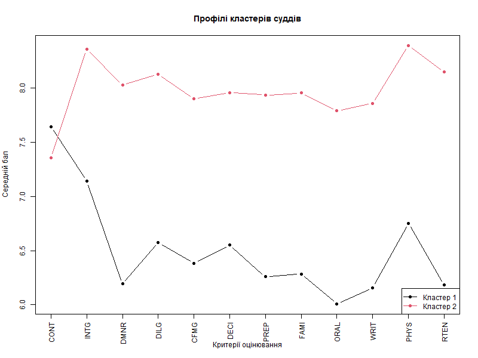

## 6. Аналіз аномалій (DBSCAN) — Додаткове завдання

Для пошуку щільних груп та аномалій було застосовано алгоритм **DBSCAN** ($MinPts = 4$, $eps = 2.5$).

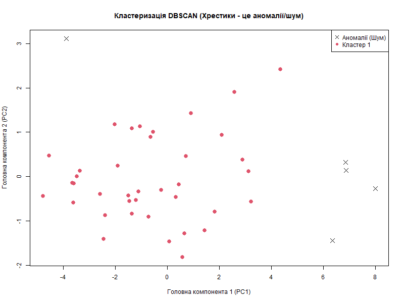

Рис 6. Результат роботи DBSCAN

## 7. Висновки

В ході лабораторної роботи було виконано комплексний кластерний аналіз рейтингу суддів. Набір даних найкраще розділяється на 2 кластери: висококваліфіковані судді та судді з нижчим рейтингом. Ітеративні методи показали високу узгодженість, а застосування DBSCAN дозволило додатково ізолювати нетипові оцінки.В ході роботи було реалізовано автоматичне збереження результатів розподілу суддів за кластерами у файл clusters_USJudgeRatings.csv. Це забезпечує можливість подальшого використання результатів аналізу в інших системах або для підготовки звітів без необхідності повторного виконання обчислень. Основна складність виникла через конфлікт шляхів до файлів між двома середовищами:

Скрипт 01_prepare.R працював у папці scripts або data, тому створював файли відносно цих папок.

Звіт report.Rmd при генерації (Knit) завжди вважає своєю робочою директорією ту папку, де він лежить (у reports).

Через це звіт постійно видавав помилку cannot open the connection, бо намагався вийти в папку data, якої він не бачив, або шукав файл clean_USJudgeRatings.csv там, де його не було.

Вирішення:

Етап 1: Оптимізація шляхів у звіті.Спробувала підправити відносні шляхи (наприклад, ../clean_…), щоб звіт міг вийти з папки reports у головну директорію проекту.

Етап 2: Метод Final Fix. Коли RStudio остаточно заплуталася в папках, застосувала найнадійнішу стратегію:

Пряме завантаження даних: Оскільки USJudgeRatings — це вбудований датасет R, я почала використовувати його напряму через data(), що зняло проблему пошуку raw-файлу.

Обчислення на льоту: Замість того, щоб звіт залежав від зовнішніх CSV-файлів (clean_… та clusters_…), прописала створення цих таблиць прямо в блоці setup всередині report.Rmd.

Виправлення логіки об’єктів: Впорядкувала код так, щоб спочатку створювалася таблиця df_scaled, а вже на її основі — clusters, що прибрало помилку object not found.

Результат: Завдяки переходу на створення даних всередині самого звіту, він став автономним. Тепер йому не страшно, якщо перейменовувати папку — він завжди згенерує правильний HTML-файл.